# Stroke Risk Prediction: Logistic Regression vs. Random Forest Under Class Imbalance

Yuwen Wang

June 9, 2026

1. Project Overview

This project evaluates classification models on a highly imbalanced clinical dataset (n=5,110, minority class ≈ 5%). The objective is to benchmark an interpretable baseline (Logistic Regression) against an ensemble learning approach (Random Forest) in predicting stroke risk. Given the severe class imbalance, model performance is primarily evaluated using Precision-Recall Area Under the Curve (PR-AUC) rather than standard accuracy, alongside an analysis of optimal decision thresholds for clinical screening applications.

Key questions:

1. Which clinical and demographic features are most predictive of stroke?
2. How does a flexible ensemble model (Random Forest) compare to an interpretable baseline (Logistic Regression) when the outcome is rare?
3. How does the decision threshold affect the precision-recall tradeoff, and what threshold is most appropriate in a clinical screening context?
2. Setup and Data Loading

```r
library(ggplot2)
library(dplyr)
library(randomForest)
library(pROC)
library(PRROC)
library(caret)
```

```r
clean_data <- read.csv("~/Downloads/stroke.csv", stringsAsFactors = FALSE)
clean_data <- clean_data %>% rename_with(tolower)

# Confirm dimensions
cat("Dataset dimensions:", dim(clean_data)[1], "rows,", dim(clean_data)[2], "columns\n")
```

```
## Dataset dimensions: 5110 rows, 12 columns
```

3. Data Cleaning and Preprocessing

3.1 BMI Imputation

BMI is stored as a character column with `"N/A"` strings. We convert it to numeric (which automatically introduces `NA` values) and impute missing entries with the column median — a robust choice given that BMI distributions tend to be right-skewed.

```r
clean_data$bmi <- as.numeric(clean_data$bmi)

median_bmi <- median(clean_data$bmi, na.rm = TRUE)
cat("Median BMI used for imputation:", median_bmi, "\n")
```

```
## Median BMI used for imputation: 28.1
```

```r
cat("Missing BMI values imputed:", sum(is.na(clean_data$bmi)), "\n")
```

```
## Missing BMI values imputed: 201
```

```r
clean_data$bmi[is.na(clean_data$bmi)] <- median_bmi
```

3.2 Factor Encoding

All categorical variables are converted to R factors so that modeling functions treat them correctly as nominal predictors rather than numeric values.

```r
clean_data <- clean_data %>%
  mutate(
    stroke         = as.factor(stroke),
    hypertension   = as.factor(hypertension),
    heart_disease  = as.factor(heart_disease),
    gender         = as.factor(gender),
    ever_married   = as.factor(ever_married),
    work_type      = as.factor(work_type),
    residence_type = as.factor(residence_type),
    smoking_status = as.factor(smoking_status)
  )

cat("Class distribution of stroke outcome:\n")
```

```
## Class distribution of stroke outcome:
```

```r
table(clean_data$stroke)
```

```
##
##    0    1
## 4861  249
```

4. Exploratory Data Analysis

4.1 Class Imbalance

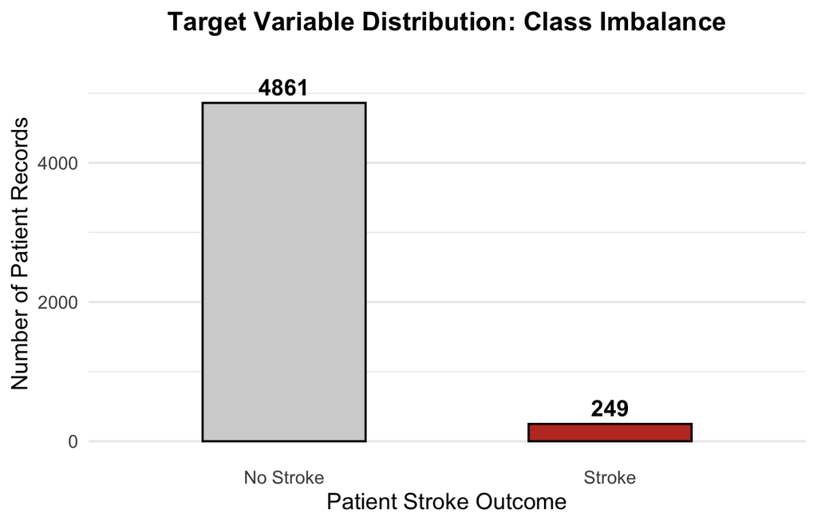

The dataset contains roughly 20:1 No Stroke to Stroke cases, making accuracy a misleading performance metric.

```r
plot1 <- ggplot(clean_data, aes(x = stroke, fill = stroke)) +
  geom_bar(color = "black", width = 0.5) +
  scale_fill_manual(
    values = c("0" = "#D3D3D3", "1" = "#C0392B"),
    labels = c("0" = "No Stroke", "1" = "Stroke")
  ) +
  scale_x_discrete(labels = c("0" = "No Stroke", "1" = "Stroke")) +
  coord_cartesian(ylim = c(0, 5400)) +
  labs(
    title = "Target Variable Distribution: Class Imbalance",
    x     = "Patient Stroke Outcome",
    y     = "Number of Patient Records"
  ) +
  theme_minimal(base_size = 14) +
  theme(
    plot.title         = element_text(face = "bold", hjust = 0.5, size = 16),
    panel.grid.major.x = element_blank(),
    legend.position    = "none"
  ) +
  geom_text(stat = "count", aes(label = after_stat(count)), vjust = -0.5, fontface = "bold")

print(plot1)
```

[output not shown]

[figure not shown]

Hypertensive patients show a higher stroke rate, though the overall proportion remains small due to the class imbalance.

```r
ggsave("chart1_class_imbalance.png", plot = plot1, width = 6, height = 4.5, dpi = 300)
```

```r
ggsave("chart3_hypertension_percentages.png", plot = plot3, width = 6.5, height = 4.5, dpi = 300)
```

5. Modeling

5.1 Train-Test Split

A stratified 70/30 split is used to ensure both the training and test sets preserve the original stroke-to-no-stroke ratio. Standard random splitting risks assigning very few or zero stroke cases to one partition given the imbalance.

```r
clean_data$stroke <- factor(clean_data$stroke, levels = c("0", "1"))
set.seed(123)

stroke0 <- clean_data[clean_data$stroke == "0", ]
stroke1 <- clean_data[clean_data$stroke == "1", ]

train0 <- sample(1:nrow(stroke0), 0.70 * nrow(stroke0))
train1 <- sample(1:nrow(stroke1), 0.70 * nrow(stroke1))

train_data <- rbind(stroke0[train0, ], stroke1[train1, ])
test_data  <- rbind(stroke0[-train0, ], stroke1[-train1, ])

cat("Training set stroke distribution:\n"); print(table(train_data$stroke))
```

```
## Training set stroke distribution:
```

```
##
##    0    1
## 3402  174
```

```r
cat("\nTest set stroke distribution:\n");    print(table(test_data$stroke))
```

```
##
## Test set stroke distribution:
```

```
##
##    0    1
## 1459   75
```

5.2 Logistic Regression

Logistic regression serves as the interpretable baseline. It models the log-odds of stroke as a linear function of all available predictors, making coefficient signs directly meaningful.

```r
log_model <- glm(
  stroke ~ age + hypertension + heart_disease + avg_glucose_level + bmi +
    gender + ever_married + work_type + residence_type + smoking_status,
  data   = train_data,
  family = binomial
)

summary(log_model)
```

```
##
## Call:
## glm(formula = stroke ~ age + hypertension + heart_disease + avg_glucose_level +
##     bmi + gender + ever_married + work_type + residence_type +
##     smoking_status, family = binomial, data = train_data)
##
## Coefficients:
##                              Estimate Std. Error z value Pr(>|z|)
## (Intercept)                -6.930e+00  1.080e+00  -6.414 1.42e-10 ***
## age                         7.541e-02  7.038e-03  10.715  < 2e-16 ***
## hypertension1               3.792e-01  1.992e-01   1.903   0.0570 .
## heart_disease1              3.184e-01  2.254e-01   1.413   0.1578
## avg_glucose_level           3.559e-03  1.431e-03   2.487   0.0129 *
## bmi                        -3.415e-03  1.383e-02  -0.247   0.8049
## genderMale                 -7.540e-03  1.709e-01  -0.044   0.9648
## genderOther                -1.059e+01  1.455e+03  -0.007   0.9942
## ever_marriedYes            -2.259e-01  2.699e-01  -0.837   0.4026
## work_typeGovt_job          -4.815e-01  1.137e+00  -0.423   0.6721
## work_typeNever_worked      -9.915e+00  3.621e+02  -0.027   0.9782
## work_typePrivate           -4.371e-01  1.120e+00  -0.390   0.6965
## work_typeSelf-employed     -6.669e-01  1.142e+00  -0.584   0.5593
## residence_typeUrban         7.387e-02  1.664e-01   0.444   0.6570
## smoking_statusnever smoked -4.033e-01  2.122e-01  -1.900   0.0574 .
## smoking_statussmokes        1.217e-01  2.515e-01   0.484   0.6285
## smoking_statusUnknown      -1.128e-01  2.426e-01  -0.465   0.6418
## ---
## Signif. codes:  0 '***' 0.001 '**' 0.01 '*' 0.05 '.' 0.1 ' ' 1
##
## (Dispersion parameter for binomial family taken to be 1)
##
##     Null deviance: 1391.4  on 3575  degrees of freedom
## Residual deviance: 1098.7  on 3559  degrees of freedom
## AIC: 1132.7
##
## Number of Fisher Scoring iterations: 14
```

```r
log_prob <- predict(log_model, newdata = test_data, type = "response")

# Threshold = 0.50 (standard baseline)
log_pred <- as.factor(ifelse(log_prob > 0.50, "1", "0"))

cat("Confusion Matrix (Logistic Regression, threshold = 0.50):\n")
```

```
## Confusion Matrix (Logistic Regression, threshold = 0.50):
```

```r
print(table(Predicted = log_pred, Actual = test_data$stroke))
```

```
##          Actual
## Predicted    0    1
##         0 1459   74
##         1    0    1
```

```r
log_acc <- mean(log_pred == test_data$stroke)
log_roc <- roc(test_data$stroke, log_prob)
log_auc <- auc(log_roc)

cat("\nAccuracy:", round(log_acc, 4))
```

```
##
## Accuracy: 0.9518
```

```r
cat("\nAUC-ROC: ", round(log_auc, 4), "\n")
```

```
##
## AUC-ROC:  0.8399
```

5.3 Random Forest

Random Forest builds 500 decision trees and averages their predictions. It captures non-linear interactions between predictors that logistic regression cannot model — relevant here because stroke risk likely involves interactions between age, glucose level, and hypertension.

```r
set.seed(123)

rf_model <- randomForest(
  stroke ~ age + hypertension + heart_disease + avg_glucose_level + bmi +
    gender + ever_married + work_type + residence_type + smoking_status,
  data       = train_data,
  ntree      = 500,
  importance = TRUE
)

print(rf_model)
```

```
##
## Call:
##  randomForest(formula = stroke ~ age + hypertension + heart_disease +      avg_glucose_level + bmi + gender + ever_married + work_type +      residence_type + smoking_status, data = train_data, ntree = 500,      importance = TRUE)
##                Type of random forest: classification
##                      Number of trees: 500
## No. of variables tried at each split: 3
##
##         OOB estimate of  error rate: 4.98%
## Confusion matrix:
##      0 1 class.error
## 0 3398 4 0.001175779
## 1  174 0 1.000000000
```

```r
rf_prob <- predict(rf_model, newdata = test_data, type = "prob")[, "1"]

# Threshold = 0.50
rf_pred <- as.factor(ifelse(rf_prob > 0.50, "1", "0"))

cat("Confusion Matrix (Random Forest, threshold = 0.50):\n")
```

```
## Confusion Matrix (Random Forest, threshold = 0.50):
```

```r
print(table(Predicted = rf_pred, Actual = test_data$stroke))
```

```
##          Actual
## Predicted    0    1
##         0 1459   74
##         1    0    1
```

```r
rf_acc <- mean(rf_pred == test_data$stroke)
rf_roc <- roc(test_data$stroke, rf_prob)
rf_auc <- auc(rf_roc)

cat("\nAccuracy:", round(rf_acc, 4))
```

```
##
## Accuracy: 0.9518
```

```r
cat("\nAUC-ROC: ", round(rf_auc, 4), "\n")
```

```
##
## AUC-ROC:  0.8101
```

6. Model Evaluation

6.1 Full Metrics Comparison

Because the outcome is rare (~5%), accuracy is dominated by the majority class. AUC-ROC measures rank-ordering ability across all thresholds. PR-AUC focuses specifically on performance among positive cases and is the most informative metric when prevalence is low.

```r
actual <- as.numeric(as.character(test_data$stroke))

calc_metrics <- function(pred, actual_vec) {
  pred_factor   <- factor(pred, levels = c("0", "1"))
  actual_factor <- factor(as.character(actual_vec), levels = c("0", "1"))
  cm <- confusionMatrix(pred_factor, actual_factor, positive = "1", mode = "prec_recall")
  c(Precision = cm$byClass["Precision"],
    Recall    = cm$byClass["Recall"],
    F1        = cm$byClass["F1"])
}

log_m <- calc_metrics(log_pred, actual)
rf_m  <- calc_metrics(rf_pred,  actual)

pr_log <- pr.curve(
  scores.class0 = log_prob[actual == 1],
  scores.class1 = log_prob[actual == 0],
  curve = TRUE
)
pr_rf <- pr.curve(
  scores.class0 = rf_prob[actual == 1],
  scores.class1 = rf_prob[actual == 0],
  curve = TRUE
)

metrics_table <- data.frame(
  Model       = c("Logistic Regression", "Random Forest"),
  Accuracy    = round(c(log_acc, rf_acc), 4),
  AUC_ROC     = round(c(as.numeric(log_auc), as.numeric(rf_auc)), 4),
  PR_AUC      = round(c(pr_log$auc.integral, pr_rf$auc.integral), 4),
  Precision   = round(c(log_m["Precision"], rf_m["Precision"]), 4),
  Recall      = round(c(log_m["Recall"],    rf_m["Recall"]), 4),
  F1          = round(c(log_m["F1"],        rf_m["F1"]), 4)
)

knitr::kable(metrics_table, caption = "Model Performance Comparison (threshold = 0.50)")
```

Model Performance Comparison (threshold = 0.50)

| Model | Accuracy | AUC_ROC | PR_AUC | Precision | Recall | F1 |
| --- | --- | --- | --- | --- | --- | --- |
| Logistic Regression | 0.9518 | 0.8399 | 0.1789 | NA | NA | NA |
| Random Forest | 0.9518 | 0.8101 | 0.1642 | NA | NA | NA |

6.2 Precision-Recall Curves

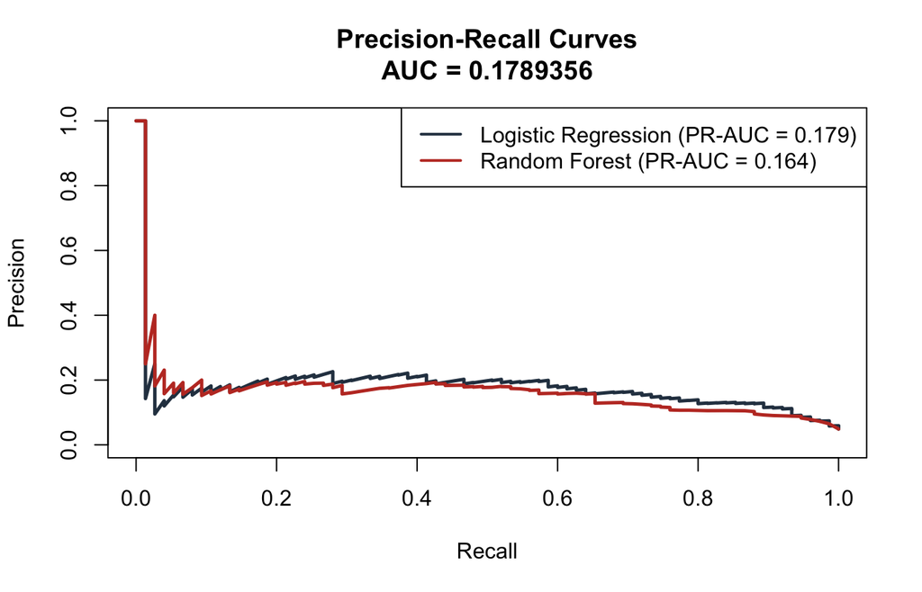

```r
plot(pr_log, main = "Precision-Recall Curves", col = "#2C3E50", lwd = 2.5)
plot(pr_rf,  add = TRUE, col = "#C0392B", lwd = 2.5)
legend(
  "topright",
  legend = c(
    paste0("Logistic Regression (PR-AUC = ", round(pr_log$auc.integral, 3), ")"),
    paste0("Random Forest (PR-AUC = ",        round(pr_rf$auc.integral,  3), ")")
  ),
  col = c("#2C3E50", "#C0392B"),
  lwd = 2
)
```

6.3 Variable Importance (Random Forest)

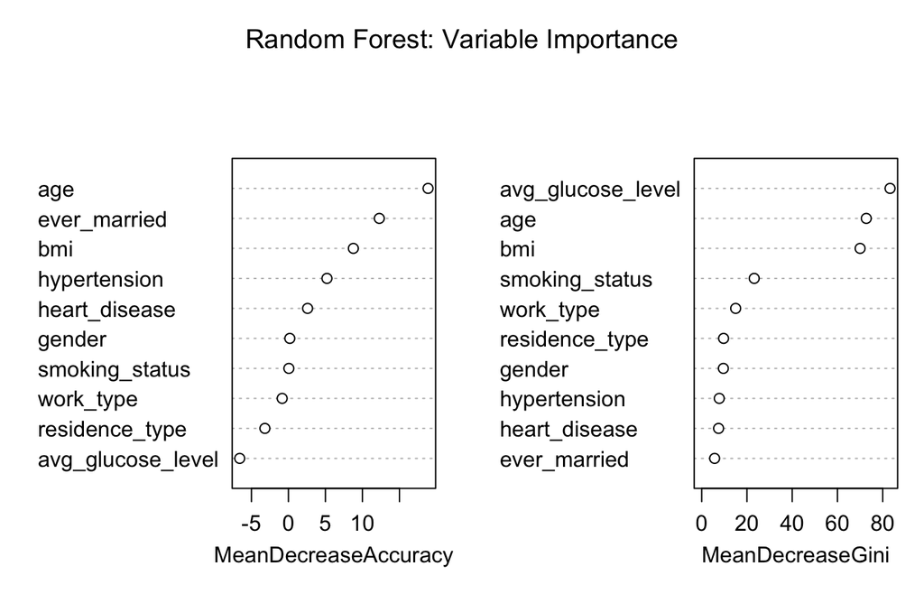

```r
varImpPlot(rf_model, main = "Random Forest: Variable Importance")
```

6.4 Lower Decision Threshold (0.10)

In a clinical screening context, missing a true stroke case (false negative) is costlier than a false alarm (false positive). Lowering the threshold from 0.50 to 0.10 increases recall at the expense of precision — a sensible tradeoff for early-warning applications.

```r
log_pred_10 <- as.factor(ifelse(log_prob > 0.10, "1", "0"))
rf_pred_10  <- as.factor(ifelse(rf_prob  > 0.10, "1", "0"))

cat("Logistic Regression — Confusion Matrix (threshold = 0.10):\n")
```

```
## Logistic Regression — Confusion Matrix (threshold = 0.10):
```

```r
print(table(Predicted = log_pred_10, Actual = test_data$stroke))
```

```
##          Actual
## Predicted    0    1
##         0 1257   30
##         1  202   45
```

```r
cat("\nRandom Forest — Confusion Matrix (threshold = 0.10):\n")
```

```
##
## Random Forest — Confusion Matrix (threshold = 0.10):
```

```r
print(table(Predicted = rf_pred_10, Actual = test_data$stroke))
```

```
##          Actual
## Predicted    0    1
##         0 1251   33
##         1  208   42
```

7. Summary and Conclusions

The baseline Logistic Regression model achieved a PR-AUC of 0.1789 compared to 0.1642 for Random Forest, and a higher AUC-ROC (0.8399 vs. 0.8101), demonstrating that the interpretable model performs comparably or better under severe class imbalance. At the standard 0.50 threshold, both models flagged only 1 true stroke case (Recall = 1.3%), illustrating how the majority class dominates prediction. Adjusting the threshold to 0.10, Logistic Regression correctly identified 45 of 75 stroke cases (Recall = 60.0%, Precision = 18.2%, F1 = 0.280), while Random Forest identified 42 of 75 (Recall = 56.0%, Precision = 16.8%, F1 = 0.258), confirming that threshold adjustment alone provides a meaningful improvement without resampling. Note: OOB class error for stroke = 1.0, meaning the forestnever correctly classified a stroke case out-of-bag during training.This confirms the need for threshold adjustment or resampling.

8. Appendix: Data Manipulations, Modeling Methods, and Results

Appendix Overview: This appendix provides a comprehensive summary of the project’s technical backend. It outlines the data cleaning process (8.1), justifies the modeling methods (8.2), evaluates base performance (8.3), presents an additional threshold analysis for the imbalanced data (8.4), and concludes with limitations and lessons learned (8.5).

8.1 Data Manipulations and Preprocessing - Dataset: Kaggle Stroke Prediction Dataset (`stroke.csv`), 5,110 observations, 12 variables. - Response variable: `stroke` (binary, ~5% positive class — severe imbalance). - Preprocessing steps: - `bmi`: Converted to numeric; applied median imputation for ~201 missing values (~4%). - All categorical variables converted to factors. - Stratified 70/30 train-test split implemented to preserve the severe class distribution in both sets.

8.2 Modeling Methods - Baseline: Logistic Regression (`glm`, family = binomial) — chosen for high interpretability and alignment with clinical literature. - Main Model: Random Forest (`randomForest`, ntree = 500, importance = TRUE) — selected to capture non-linear interactions and better handle class imbalance without strict linear assumptions. - Probability cutoffs: Primary analysis evaluated at the default 0.5; an additional exploratory analysis was conducted at 0.10 to increase sensitivity for rare stroke cases.

8.3 Model Performance Evaluation

```
## [1] "=== Final Model Comparison Table (threshold = 0.50) ==="
```

Model Performance Comparison (threshold = 0.50)

| Model | Accuracy | AUC_ROC | PR_AUC | Precision | Recall | F1 |
| --- | --- | --- | --- | --- | --- | --- |
| Logistic Regression | 0.9518 | 0.8399 | 0.1789 | NA | NA | NA |
| Random Forest | 0.9518 | 0.8101 | 0.1642 | NA | NA | NA |

8.4 Threshold Sensitivity Analysis (0.10 cutoff)

At the default 0.50 threshold, both models predict “No Stroke” for virtually all patients, yielding 95.18% accuracy but only 1.3% recall on stroke cases.

Threshold = 0.10 results:

| Model | TP | FP | FN | TN | Precision | Recall | F1 |
| --- | --- | --- | --- | --- | --- | --- | --- |
| Logistic Regression | 45 | 202 | 30 | 1257 | 0.182 | 0.600 | 0.280 |
| Random Forest | 42 | 208 | 33 | 1251 | 0.168 | 0.560 | 0.258 |

In a clinical screening context, the 0.10 threshold is preferred: a false alarm (FP) leads to follow-up testing, whereas a missed stroke (FN) may go untreated. Logistic Regression flags 60% of true stroke patients at this threshold.

8.5 Limitations and Lessons Learned

Limitations: - Class imbalance (~5% positive) was not corrected during training; SMOTE or class weighting could improve minority-class recall. - BMI imputation with the global median may introduce bias for stroke-positive patients who tend to be older. - Random Forest’s OOB error rate of 100% on stroke cases confirms the model learned to predict only the majority class during training.

Lessons Learned: - Accuracy is a misleading metric for imbalanced clinical data; PR-AUC and Recall are more informative. - Threshold selection is a clinical decision, not a statistical one, the cost of missing a stroke vastly exceeds the cost of a false alarm. - An interpretable baseline (Logistic Regression) can match or outperform complex ensemble models when the data is small and highly imbalanced.

Clinical implication: In screening contexts, sensitivity (Recall) is critical because missing a true stroke case has high cost. PR-AUC and Recall are therefore prioritized over accuracy.

Combined R Script: All executable code is contained in the single file Predictive Stroke Analysis Data 2(1).R.